# Formula 17

8 actividades, 4 rutas; τ como norma infinito

# Enunciado

La duración de un proyecto puede escribirse como una fórmula cerrada: si $R$ es la matriz de rutas (una fila por cada ruta del nodo inicial al final, una columna por actividad, con un 1 donde la actividad pertenece a la ruta) y $t$ el vector de duraciones, entonces

$$\tau = \lVert R\,t \rVert_\infty = \max_r \sum_i R_{ri}\,t_i .$$

Considere el proyecto cuyo cuadro de prelaciones y duraciones (días) se adjunta.

1. Dibuje el grafo PERT, enumere sus rutas y construya la matriz de rutas R. ¿Qué dimensiones tiene?

2. Calcule el vector R·t y su norma infinito. Compruebe que coincide con el tiempo más temprano del último nodo obtenido por el método de Zaderenko.

3. ¿Por qué la norma infinito y no otra? ¿Qué daría ‖R·t‖₁? ¿Y qué significaría el mínimo de R·t?

4. Escriba τ en función de t_G (la duración de G) dejando fijas las demás, y dibuje esa función. ¿Es lineal? ¿Dónde cambia de pendiente?

Tabla 1: Cuadro de datos del enunciado

| activity | predecessor | duration |
| --- | --- | --- |
| A | --- | 8 |
| B | --- | 5 |
| C | A,B | 5 |
| D | B | 8 |
| E | C | 7 |
| F | D | 7 |
| G | E | 3 |
| H | D,G | 8 |

El proyecto corresponde a la instalación de una planta fotovoltaica sobre cubierta; las actividades son las siguientes (las duraciones del cuadro están en días).

Tabla 2: Descripción de las actividades

|  | Descripción |
| --- | --- |
| A | Estudio de sombras y producción |
| B | Cálculo estructural de la cubierta |
| C | Tramitación de permisos |
| D | Acopio de módulos e inversores |
| E | Montaje de la estructura soporte |
| F | Colocación de módulos |
| G | Cableado de corriente continua |
| H | Instalación de inversores |

# Resolución

## Apartado 1

1. Dibuje el grafo PERT, enumere sus rutas y construya la matriz de rutas R. ¿Qué dimensiones tiene?

[figure not shown]

Figura 1: Grafo Roy

Tabla 3: Matriz de rutas R

|  | actividades |
| --- | --- |
| Route_1 | A - C - E - G - H |
| Route_2 | B - C - E - G - H |
| Route_3 | B - D - F |
| Route_4 | B - D - H |

[figure not shown]

ninguna ruta (0 de 4)

[figure not shown]

👆 **Interactivo:** haz clic en una fila de la matriz para resaltar en el grafo las actividades y los nodos de esa ruta (otro clic la deselecciona), o usa los botones y las flechas del teclado.

**Respuesta:** el grafo tiene 4 rutas del nodo inicial al final (tabla); R tiene 4 filas (una por ruta) y 8 columnas (una por actividad real; las ficticias duran 0 y no se incluyen): dimensiones 4 × 8.

## Apartado 2

2. Calcule el vector R·t y su norma infinito. Compruebe que coincide con el tiempo más temprano del último nodo obtenido por el método de Zaderenko.

ninguna ruta (0 de 4)

|  | A | B | C | D | E | F | G | H |
| --- | --- | --- | --- | --- | --- | --- | --- | --- |
| Route_1 | 1 | 0 | 1 | 0 | 1 | 0 | 1 | 1 |
| Route_2 | 0 | 1 | 1 | 0 | 1 | 0 | 1 | 1 |
| Route_3 | 0 | 1 | 0 | 1 | 0 | 1 | 0 | 0 |
| Route_4 | 0 | 1 | 0 | 1 | 0 | 0 | 0 | 1 |

×

|  | duration |
| --- | --- |
| A | 8 |
| B | 5 |
| C | 5 |
| D | 8 |
| E | 7 |
| F | 7 |
| G | 3 |
| H | 8 |

=

| duration |
| --- |
| 31 |
| 28 |
| 20 |
| 21 |

👆 Interactivo: pasa el ratón (o toca) una fila de la matriz de rutas: se recuadran los valores que se suman y el resultado. También con los botones y las flechas del teclado.

Cada componente de $R\,t$ es el producto de una fila de $R$ por $t$: como la fila tiene un 1 en las actividades de la ruta y un 0 en las demás, el producto es la suma de las duraciones de esa ruta. La norma infinito es el mayor de esos valores.

|  | actividades | fila de R · t = suma | R·t | máximo |
| --- | --- | --- | --- | --- |
| Route_1 | A – C – E – G – H | A(8) + C(5) + E(7) + G(3) + H(8) = 31 | 31.0 | ← τ |
| Route_2 | B – C – E – G – H | B(5) + C(5) + E(7) + G(3) + H(8) = 28 | 28.0 |  |
| Route_3 | B – D – F | B(5) + D(8) + F(7) = 20 | 20.0 |  |
| Route_4 | B – D – H | B(5) + D(8) + H(8) = 21 | 21.0 |  |

τ = ‖R·t‖∞ = máx(31, 28, 20, 21) = **31 días**, que corresponde a la ruta Route_1 (A – C – E – G – H).

Algoritmo de Zaderenko paso a paso, con el grafo PERT arriba y la matriz debajo. El primer paso muestra el resultado final; a partir del siguiente se construye desde el principio (avance con los botones):

Tabla 4: Matriz de Zaderenko

[figure not shown]

paso 0 de 18

[figure not shown]

**Respuesta:** R·t = (31, 28, 20, 21) y ‖R·t‖∞ = 31 días; el tiempo más temprano del último nodo por Zaderenko es 31 días y la librería (`proyecto.tau`) da 31. Las tres coinciden: el cálculo de tiempos hacia delante es una forma de calcular el máximo de las rutas sin enumerarlas.

## Apartado 3

3. ¿Por qué la norma infinito y no otra? ¿Qué daría ‖R·t‖₁? ¿Y qué significaría el mínimo de R·t?

**Respuesta:** ‖R·t‖₁ = 31 + 28 + 20 + 21 = 100 sumaría las duraciones de todas las rutas, contando varias veces cada actividad compartida: no tiene sentido como plazo. El mínimo de R·t, 20 (Route_3), es la ruta más corta: el tiempo que *como mínimo* ocupa cualquier cadena del proyecto, pero el proyecto no termina hasta que acaba la última ruta. El plazo es el máximo porque todas las rutas deben completarse; de ahí la norma infinito.

## Apartado 4

4. Escriba τ en función de t_G (la duración de G) dejando fijas las demás, y dibuje esa función. ¿Es lineal? ¿Dónde cambia de pendiente?

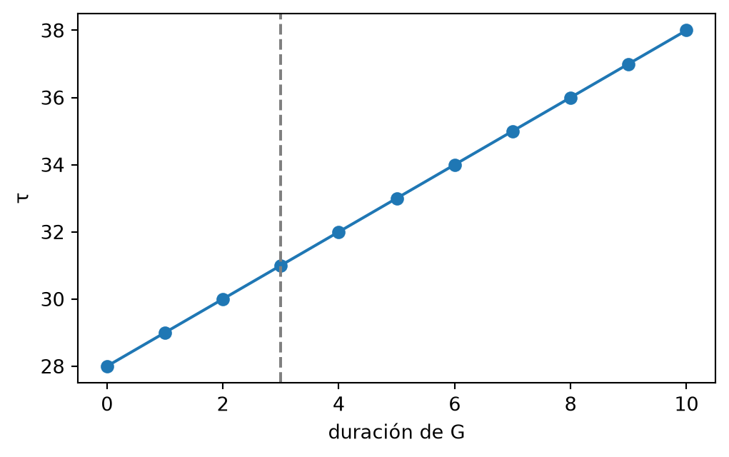

**Respuesta:** τ(t_G) = máx(21, 28 + t_G) = 28 + t_G para cualquier t_G ≥ 0, porque la ruta más larga con G (Route_1) ya supera sin G a la más larga sin G (Route_4, 21): pendiente 1 en todo el dominio, sin cambio de pendiente. En el rango de duraciones posibles es lineal; con t_G = 3, G está en la ruta crítica: alargarla o acortarla un día cambia τ un día (pendiente 1).